# BRIDGE EQ5D VAS starter

Astrid

2022-08-12

## Source Data

BRIDGE follow-up datasets for all sites.  
Data in this version was pulled on 8/8/2022 using REDCapDB.Rmd and BRIDGE_DatIn_rename.R.  
I try to redo every step in Zilu’s markdown and compare mine to hers.

## Check N

For EUC(enhanced usual care): Mine is 893, Zilu’s is 890  
For TSC(intervention arm): Mine is 899, Zilu’s is 888

A good news is that the numbers of unique participants with any follow-up care form records increased(from 98.3% to 99.1%, from 96.2% to 97.3%).

Number of unique participants in follow up dataset

| study_arm | n |
| --- | --- |
| EUC | 893 |
| TSC | 899 |

Number of unique participants with any follow-up care form records

| study_arm | n | pct |
| --- | --- | --- |
| EUC | 885 | 99.1% |
| TSC | 875 | 97.3% |

## TO DO: locate variables that suggest missed visit

## Not sure about missed_fu variable

Only the NA part increases extremely(from 9097 to 14131).  
The variable, missed_fu(Question: If this follow-up was missed, why was it missed?) is not mandatory so many responses are just left blank.

missed_fu should indicate if this follow-up was missed and why

| missed_fu | mean_qolie | freq |
| --- | --- | --- |
| NA | 71.58081 | 14131 |
| No | 71.46743 | 261 |
| No missed | 74.00000 | 63 |
| None | 79.40909 | 44 |
| N0 | 76.28947 | 38 |
| Visit not done. | 47.22222 | 21 |
| CHW was very sick | 53.33333 | 12 |
| Not missed | 79.33333 | 12 |
| Visit not done | 50.00000 | 11 |
| 0 | 70.10000 | 10 |
| Security challenges | 52.10000 | 10 |
| Yes because of insecurity | 50.00000 | 10 |
| Patient travelled | 52.77778 | 9 |
| There is no movement in both legs | 42.11111 | 9 |
| I gave birth at the exact follow up time | 68.75000 | 8 |
| Mistakely deleted | 56.25000 | 8 |
| NO | 93.12500 | 8 |
| I was sick | 58.57143 | 7 |
| They travelled | 65.33333 | 6 |
| Yes because of insecurity and lack of fund | 50.00000 | 6 |
| Child’s community has been cleared by kidnappers and not reachable | 50.00000 | 5 |
| I was sick at follow up time | 55.00000 | 5 |
| Visit not done - Unseriousness from the chew ( Rahama Aliyu) | 50.00000 | 5 |
| Child traveled | 50.00000 | 4 |
| I was sick. | 52.75000 | 4 |
| lost Contact with patient at Follow up time, address of patient cannot be traced. It was later the patient was located at month 4 follow up time, but missed Wk1,M1 and M2 Follow ups. | 50.00000 | 4 |
| Miscalculation of follow up calendars | 50.00000 | 4 |
| The patient travel | 50.00000 | 4 |
| Visit done, the CHW was sick. | 100.00000 | 4 |
| visit not done. | 50.00000 | 4 |

[output cut: 535 more lines]

## Check number of visits

Participants contribute different number of follow-up visit records.

Note: Each digit means one instance for follow up care form. So “11111111” means the participant contributes 8 visits (instance 1-8).

Now the majority is 11111111(seems like most of them have finished the 8 visits).

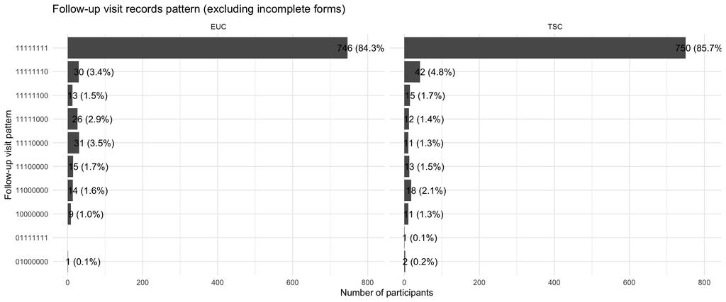

Missing follow-up visit 1

| city | study_arm | n |
| --- | --- | --- |
| Kaduna | TSC | 1 |
| Kano | EUC | 1 |
| Kano | TSC | 2 |

The number of patients missing the first visit decreased, which is puzzling – maybe they gave a made-up for the form.

## Calculating EQ5D VAS scores (including zero score)

Based on the codes, I think the VAS scores are obtained from the follow up care form. Is it a visual evaluation version of EQ-5D, as it doesn’t look like to the original self-report EQ-5Q?

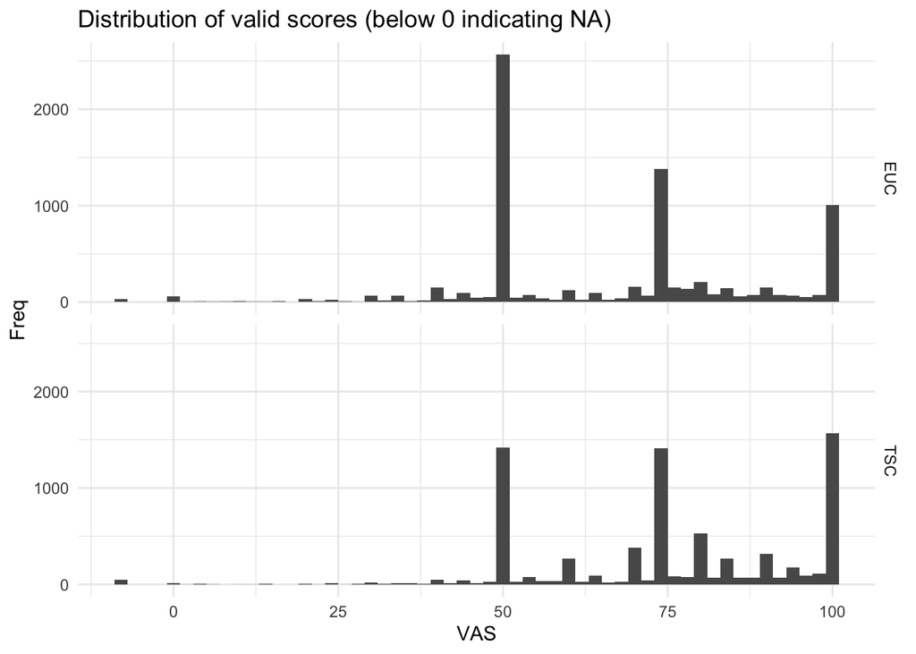

- Compared to Zilu’s, there’s a significantly higher bar for VAS = 100 in the TSC arm. Looks consistent with the expected effect of our intervention.

Summary Tables

1. **Average score per patient**

NA ignored, averaging all fu visits at patient level (including zero) Only count patients with at least one valid score.

EQ5D VAS

| item | TSC_total | TSC_N | TSC_per_patient | EUC_total | EUC_N | EUC_per_patient | diff |
| --- | --- | --- | --- | --- | --- | --- | --- |
| Average score per patient | 65292.68 | 872 | 74.87692 | 58408.2 | 885 | 65.99797 | 8.878954 |

2. **Split by follow-up visit**

One patient only has one record for each visit, so no scores are averaged.

EQ5D VAS Split up follow-up

| visit | TSC_total | TSC_N | TSC_per_patient | EUC_total | EUC_N | EUC_per_patient | diff |
| --- | --- | --- | --- | --- | --- | --- | --- |
| 1 | 49976 | 855 | 58.45146 | 45068 | 871 | 51.74282 | 6.708638 |
| 2 | 55778 | 854 | 65.31382 | 47691 | 873 | 54.62887 | 10.684951 |
| 3 | 57209 | 838 | 68.26850 | 50737 | 857 | 59.20303 | 9.065463 |
| 4 | 60218 | 827 | 72.81499 | 53146 | 841 | 63.19382 | 9.621177 |
| 5 | 61641 | 817 | 75.44798 | 54693 | 813 | 67.27306 | 8.174918 |
| 6 | 64108 | 805 | 79.63727 | 56508 | 789 | 71.61977 | 8.017495 |
| 7 | 65964 | 793 | 83.18285 | 57892 | 775 | 74.69935 | 8.483495 |
| 8 | 65456 | 751 | 87.15846 | 59012 | 745 | 79.21074 | 7.947717 |
| 9 | 62595 | 710 | 88.16197 | 54856 | 694 | 79.04323 | 9.118744 |
| 10 | 33984 | 372 | 91.35484 | 30848 | 394 | 78.29442 | 13.060422 |

3. **By visit - gender**

There is one unspecified gender value in EUC, excluded for now.

EQ5D VAS Split up follow-up and gender

| gender | visit | TSC_total | TSC_N | TSC_per_patient | EUC_total | EUC_N | EUC_per_patient | diff |
| --- | --- | --- | --- | --- | --- | --- | --- | --- |
| Male | 1 | 32667 | 549 | 59.50273 | 28540 | 559 | 51.05546 | 8.447276 |
| Male | 2 | 36159 | 553 | 65.38698 | 30425 | 560 | 54.33036 | 11.056623 |
| Male | 3 | 36544 | 542 | 67.42435 | 32438 | 548 | 59.19343 | 8.230924 |
| Male | 4 | 39006 | 534 | 73.04494 | 33746 | 537 | 62.84171 | 10.203231 |
| Male | 5 | 39964 | 530 | 75.40377 | 34729 | 519 | 66.91522 | 8.488552 |
| Male | 6 | 41348 | 521 | 79.36276 | 36220 | 506 | 71.58103 | 7.781736 |
| Male | 7 | 42707 | 514 | 83.08755 | 36982 | 498 | 74.26104 | 8.826505 |
| Male | 8 | 43147 | 493 | 87.51927 | 37845 | 474 | 79.84177 | 7.677498 |
| Male | 9 | 41157 | 466 | 88.31974 | 35231 | 444 | 79.34910 | 8.970643 |
| Male | 10 | 22464 | 245 | 91.68980 | 18714 | 239 | 78.30126 | 13.388541 |
| Female | 1 | 17309 | 306 | 56.56536 | 16528 | 312 | 52.97436 | 3.591000 |
| Female | 2 | 19619 | 301 | 65.17940 | 17266 | 313 | 55.16294 | 10.016463 |
| Female | 3 | 20665 | 296 | 69.81419 | 18299 | 309 | 59.22006 | 10.594124 |
| Female | 4 | 21212 | 293 | 72.39590 | 19400 | 304 | 63.81579 | 8.580115 |
| Female | 5 | 21677 | 287 | 75.52962 | 19964 | 294 | 67.90476 | 7.624855 |
| Female | 6 | 22760 | 284 | 80.14085 | 20288 | 283 | 71.68905 | 8.451799 |
| Female | 7 | 23257 | 279 | 83.35842 | 20910 | 277 | 75.48736 | 7.871058 |
| Female | 8 | 22309 | 258 | 86.46899 | 21167 | 271 | 78.10701 | 8.361981 |
| Female | 9 | 21438 | 244 | 87.86066 | 19625 | 250 | 78.50000 | 9.360656 |
| Female | 10 | 11520 | 127 | 90.70866 | 12134 | 155 | 78.28387 | 12.424790 |

## Exploring intervals between follow-up visits

Still mostly conformed with scheduled time.

**Expected schedule of follow-up visits** Only the first follow-up needs to be +/- 3 days, all else allow +/- 14 days.  
*Schedule:*  
* instance 1 - Week 1  
* instance 2 - Month 1  
* instance 3 - Month 2  
* instance 4 - Month 4  
* instance 5 - Month 6  
* instance 6 - Month 9  
* instance 7 - Month 12  
* instance 8 - Month 15  
* instance 9 - Month 18  
* instance 10 - Month 24  
*Expected time interval:*  
* v1: 7 +/- 3 from v0  
* v2: 28 +/- 14 from v0  
* v3: 28 +/- 14 from v2  
* v4: 56 +/- 14 from v3  
* v5: 56 +/- 14 from v4  
* v6: 84 +/- 14 from v5  
* v7: 84 +/- 14 from v6  
* v8: 84 +/- 14 from v7  
* v9: 84 +/- 14 from v8  
* v10: 168 +/- 14 from v9?

number of records missing follow-up date

| study_arm | visit | n |
| --- | --- | --- |
| EUC | 3 | 1 |
| EUC | 4 | 2 |
| TSC | 1 | 1 |
| TSC | 2 | 3 |
| TSC | 5 | 1 |
| TSC | 9 | 1 |
| TSC | 10 | 1 |

```
## In the following table, column d01 describes time interval between baseline and the first follow-up vist; d12 describes time interval between 1st and 2nd visit.
```

Range of intervals between follow up visits, EUC

|  | d01 | d12 | d23 | d34 | d45 | d56 | d67 | d78 |
| --- | --- | --- | --- | --- | --- | --- | --- | --- |
|  | Min. :-28.000 | Min. :-40.00 | Min. : 0.00 | Min. : 0.00 | Min. :-12.00 | Min. : 0.00 | Min. : 0.0 | Min. : 40.00 |
|  | 1st Qu.: 7.000 | 1st Qu.: 21.00 | 1st Qu.:28.00 | 1st Qu.: 56.00 | 1st Qu.: 56.00 | 1st Qu.: 83.00 | 1st Qu.: 84.0 | 1st Qu.: 83.00 |
|  | Median : 7.000 | Median : 21.00 | Median :28.00 | Median : 56.00 | Median : 56.00 | Median : 84.00 | Median : 84.0 | Median : 84.00 |
|  | Mean : 8.579 | Mean : 22.09 | Mean :28.49 | Mean : 54.79 | Mean : 55.54 | Mean : 83.23 | Mean : 84.3 | Mean : 84.02 |
|  | 3rd Qu.: 8.000 | 3rd Qu.: 21.00 | 3rd Qu.:28.00 | 3rd Qu.: 56.00 | 3rd Qu.: 56.00 | 3rd Qu.: 84.00 | 3rd Qu.: 85.0 | 3rd Qu.: 84.00 |
|  | Max. :154.000 | Max. :121.00 | Max. :85.00 | Max. :129.00 | Max. :219.00 | Max. :183.00 | Max. :161.0 | Max. :174.00 |
|  | NA’s :9 | NA’s :18 | NA’s :33 | NA’s :49 | NA’s :78 | NA’s :104 | NA’s :117 | NA’s :147 |

Range of intervals between follow up visits, TSC

|  | d01 | d12 | d23 | d34 | d45 | d56 | d67 | d78 |
| --- | --- | --- | --- | --- | --- | --- | --- | --- |
|  | Min. :-307.000 | Min. :-10.00 | Min. :-338.00 | Min. :-49.00 | Min. : -7.0 | Min. :-651.00 | Min. :-652.00 | Min. : 0.00 |
|  | 1st Qu.: 7.000 | 1st Qu.: 21.00 | 1st Qu.: 28.00 | 1st Qu.: 56.00 | 1st Qu.: 56.0 | 1st Qu.: 84.00 | 1st Qu.: 84.00 | 1st Qu.: 84.00 |
|  | Median : 7.000 | Median : 21.00 | Median : 28.00 | Median : 56.00 | Median : 56.0 | Median : 84.00 | Median : 84.00 | Median : 84.00 |
|  | Mean : 7.656 | Mean : 22.93 | Mean : 28.83 | Mean : 54.78 | Mean : 55.5 | Mean : 82.31 | Mean : 84.55 | Mean : 84.68 |
|  | 3rd Qu.: 8.000 | 3rd Qu.: 23.00 | 3rd Qu.: 28.00 | 3rd Qu.: 56.00 | 3rd Qu.: 56.0 | 3rd Qu.: 84.00 | 3rd Qu.: 84.00 | 3rd Qu.: 84.00 |
|  | Max. : 103.000 | Max. :153.00 | Max. : 169.00 | Max. :423.00 | Max. :112.0 | Max. : 157.00 | Max. : 821.00 | Max. :821.00 |
|  | NA’s :28 | NA’s :39 | NA’s :55 | NA’s :68 | NA’s :80 | NA’s :91 | NA’s :106 | NA’s :148 |

For every visit:

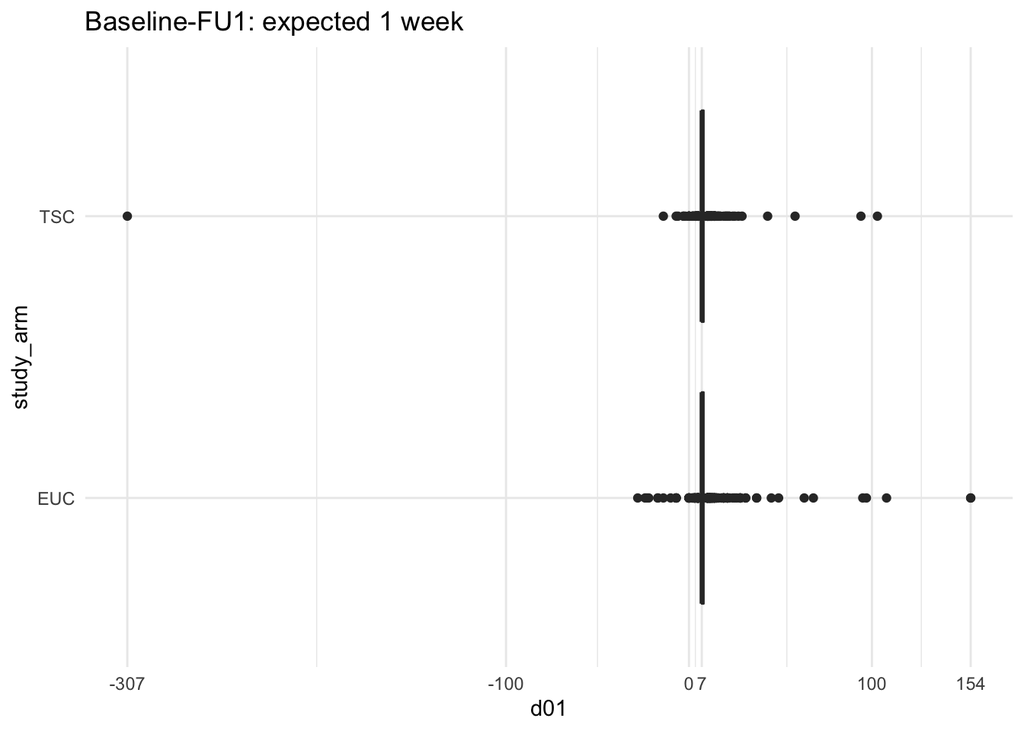

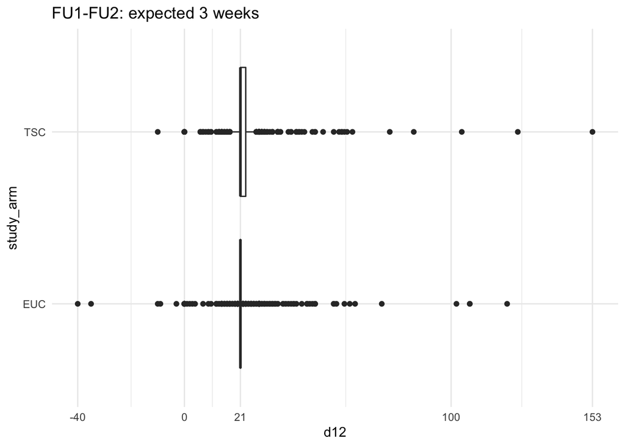

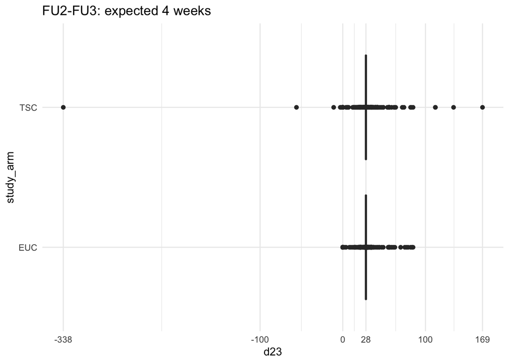

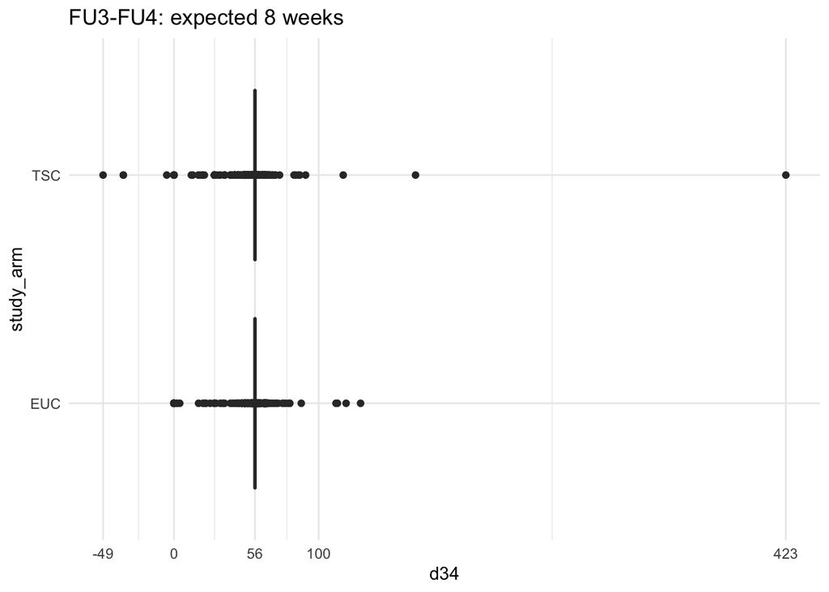

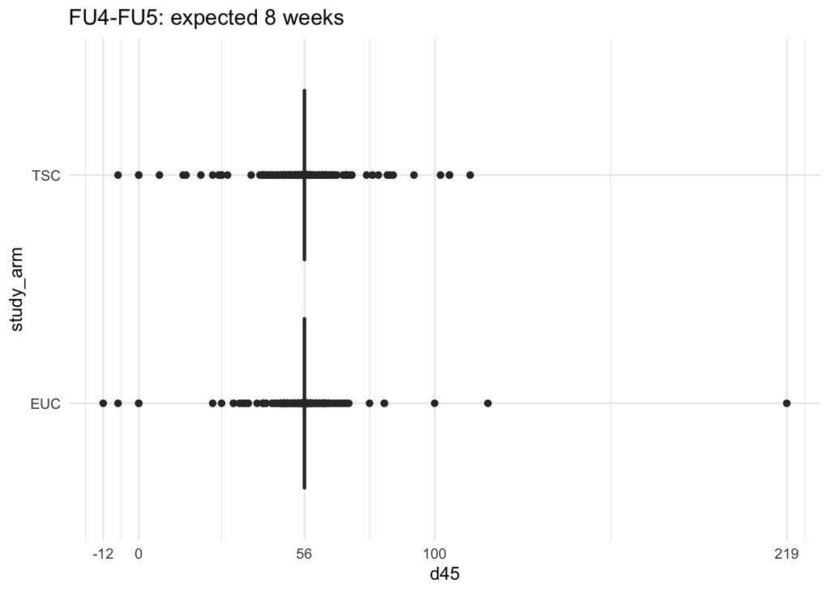

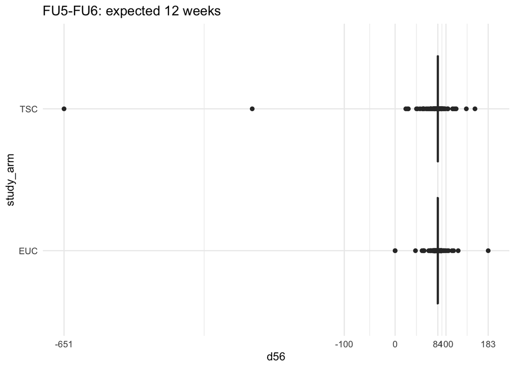

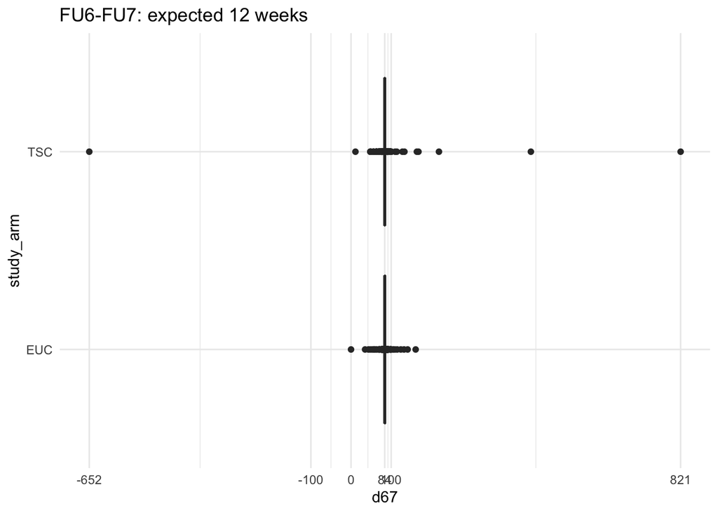

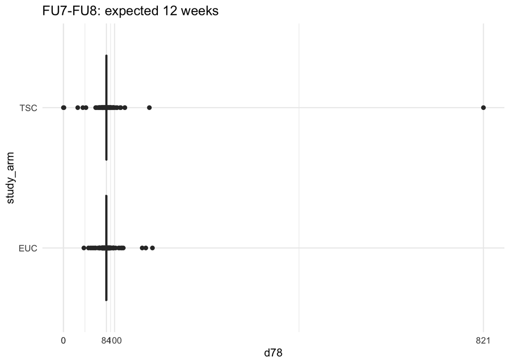

**Check time interval exclusions**  
## TODO: apply time interval exclusion

## Missing VAS score (Updated on Aug 12)

The table below describes missing (NA) EQ5D VAS scores in all follow-up care form records. Missing score affects less than 1% of all records(also less than Zilu’s calculation. EUC from 0.59% to 0.40%, TSC from 0.83% to 0.65%).

Missing EQ5D VAS scores

| study_arm | tot_record | miss_record | pct_miss_record | tot_headcount | anymiss_headcount | lost_headcount | pct_anymiss_headcount |
| --- | --- | --- | --- | --- | --- | --- | --- |
| EUC | 7683 | 31 | 0.40% | 885 | 28 | 0 | 3.2% |
| TSC | 7672 | 50 | 0.65% | 875 | 43 | 3 | 4.9% |

Missing EQ5D VAS scores, by visit

| study_arm | redcap_repeat_instance | tot_record | miss_record | pct_miss_record |
| --- | --- | --- | --- | --- |
| EUC | 1 | 884 | 13 | 1.4706% |
| EUC | 2 | 876 | 3 | 0.3425% |
| EUC | 3 | 861 | 4 | 0.4646% |
| EUC | 4 | 846 | 5 | 0.5910% |
| EUC | 5 | 815 | 2 | 0.2454% |
| EUC | 6 | 789 | 0 | 0.0000% |
| EUC | 7 | 776 | 1 | 0.1289% |
| EUC | 8 | 746 | 1 | 0.1340% |
| EUC | 9 | 695 | 1 | 0.1439% |
| EUC | 10 | 395 | 1 | 0.2532% |
| TSC | 1 | 872 | 17 | 1.9495% |
| TSC | 2 | 864 | 10 | 1.1574% |
| TSC | 3 | 844 | 6 | 0.7109% |
| TSC | 4 | 831 | 4 | 0.4813% |
| TSC | 5 | 820 | 3 | 0.3659% |
| TSC | 6 | 808 | 3 | 0.3713% |
| TSC | 7 | 793 | 0 | 0.0000% |
| TSC | 8 | 751 | 0 | 0.0000% |
| TSC | 9 | 715 | 5 | 0.6993% |
| TSC | 10 | 374 | 2 | 0.5348% |